# AD project notebook

Ian Brettell

Initial setup:

```r
install.packages("here")
install.packages("tidyverse")
install.packages("rafalib")
install.packages("dummies")
source("https://bioconductor.org/biocLite.R")
biocLite("limma")
install.packages("yaml")
install.packages("backports")
install.packages("reshape2")
install.packages("viridis")
biocLite("made4")
install.packages("caret")
install.packages('e1071', dependencies=TRUE)
install.packages("ggfortify")
install.packages("cluster")
install.packages("factoextra")
biocLite("Biobase")
biocLite("limma")

# Note: Installing bioconductor created issues with creating the markdown preview, which appears to be fixed by installing the `yaml`, `backports` and `reshape2` packages afterwards.
```

## 1. Exploratory analysis of mRNA expression data

*7 December 2017*

Import files

```r
library(here)
exdata <- read.delim(here("Data", "Expression", "AIBL_Gene_Expression.txt"), sep = " ", header = T)
dim(exdata)
```

```
[1] 22011   218
```

```r
head(exdata)
```

|  | X100 | X102 | X103 | X104 | X105 | X106 | X107 | X108 | X109 | X111 | X112 | X114 | X115 | X116 | X117 | X118 | X121 | X123 | X124 | X125 | X126 | X127 | X128 | X129 | X130 | X135 | X136 | X139 | X140 | … |
| --- | --- | --- | --- | --- | --- | --- | --- | --- | --- | --- | --- | --- | --- | --- | --- | --- | --- | --- | --- | --- | --- | --- | --- | --- | --- | --- | --- | --- | --- | --- |
| 2315554 | 6.030619 | 6.165575 | 6.573792 | 6.489151 | 6.167301 | 6.162833 | 6.459433 | 6.500313 | 5.758869 | 6.255258 | 6.283379 | 6.346622 | 6.288157 | 5.949029 | 6.314319 | 5.968143 | 6.493032 | 6.167725 | 6.406573 | 5.849523 | 6.502011 | 6.135674 | 6.461849 | 6.036305 | 6.268364 | 6.323187 | 5.928358 | 5.966071 | 5.944790 | … |
| 2315633 | 6.540337 | 6.696329 | 7.037530 | 6.707376 | 6.604118 | 6.799695 | 6.796057 | 6.952976 | 6.401347 | 6.709539 | 6.765484 | 6.880260 | 6.912437 | 6.581726 | 6.779152 | 6.700227 | 7.002052 | 6.650965 | 6.689737 | 6.586282 | 6.825250 | 6.731264 | 6.400309 | 6.688572 | 6.526505 | 6.939356 | 6.802994 | 6.561388 | 6.690265 | … |
| 2315674 | 6.294170 | 6.295077 | 6.636816 | 6.504605 | 6.381816 | 6.459972 | 6.526122 | 6.675960 | 5.973544 | 6.444970 | 6.495661 | 6.345604 | 6.307653 | 6.153074 | 6.349589 | 6.380947 | 6.738490 | 6.341245 | 6.611027 | 6.054108 | 6.471669 | 6.309723 | 6.723188 | 6.164308 | 6.445091 | 6.567885 | 6.246338 | 6.119326 | 6.218748 | … |
| 2315739 | 6.049571 | 6.232016 | 6.381600 | 6.273409 | 6.381270 | 6.704779 | 6.514058 | 6.542828 | 6.042320 | 6.591385 | 6.424220 | 6.468000 | 6.363114 | 6.331987 | 6.252506 | 6.624148 | 6.578067 | 6.318249 | 6.720172 | 6.266113 | 6.580387 | 6.357371 | 6.617919 | 6.484227 | 6.197191 | 6.548507 | 6.294528 | 6.148482 | 6.373590 | … |
| 2315894 | 8.438639 | 8.290235 | 7.875573 | 8.596950 | 8.076391 | 8.590583 | 8.658526 | 8.538429 | 8.042496 | 8.389016 | 8.395555 | 8.143446 | 8.533878 | 8.352128 | 8.635744 | 8.154736 | 8.828091 | 8.426085 | 8.717953 | 8.082044 | 8.465663 | 8.256031 | 8.555241 | 8.350568 | 8.188000 | 8.399823 | 8.458825 | 8.317301 | 8.380272 | … |
| 2315918 | 6.053986 | 5.378146 | 5.618119 | 6.507528 | 5.840277 | 5.982190 | 6.296157 | 6.060075 | 5.274647 | 5.353105 | 5.346982 | 6.054692 | 6.041754 | 6.182786 | 6.440316 | 5.940083 | 5.703004 | 4.631404 | 6.257573 | 5.547268 | 5.962815 | 4.841692 | 5.396958 | 6.009194 | 6.148451 | 6.382298 | 5.523462 | 5.866791 | 5.396945 | … |

```r
metadata <- read.delim(here("Data", "Expression", "aibl-ids-6.0.0-201712010300.txt"), sep = "\t", header = T)
dim(metadata)
```

```
[1] 6863 1174
```

```r
head(metadata)
```

|  | AIBL.Id | Collection | Enrolment | Recruitment | Actigraph.Light | Actigraph.Medium | Actigraph.Hard | Actigraph.Very.Hard | Actigraph.Avg.Counts | Actigraph.Peak.Counts | Actigraph.TC.Daily..x.10.4. | Actigraph.K.Cal.Daily | CSF.Date.of.CSF | CSF.Ab42_INNX_MELB | CSF.Tau_INNX_MELB | CSF.pTAU181_INNX_MELB | CSF.Ratio_Ab42_Tau_INNX_MELB | CSF.Ratio_Ab42_pTau181_INNX_MELB | Demographic.Sex | Demographic.YearMonthOfBirth | Demographic.Classification | Demographic.Site | Demographic.Testing.Venue | Demographic.Consented | Demographic.Age.at.consent | Demographic.Demographic.Changes | Demographic.Current.Marital.Status | Demographic.Primary.Occupation | Demographic.Prim.Occ.Details | … |
| --- | --- | --- | --- | --- | --- | --- | --- | --- | --- | --- | --- | --- | --- | --- | --- | --- | --- | --- | --- | --- | --- | --- | --- | --- | --- | --- | --- | --- | --- | --- |
| 1 | 2 | 1 | AIBL Inception Cohort | AIBL | NA | NA | NA | NA | NA | NA | NA | NA |  | NA | NA | NA | NA | NA | Male | 194108 | NA | Melbourne |  | NA | NA | NA | Married | Other | minister | … |
| 2 | 2 | 2 | AIBL Inception Cohort | AIBL | NA | NA | NA | NA | NA | NA | NA | NA |  | NA | NA | NA | NA | NA | Male | 194108 | NA | Melbourne |  | NA | NA | NA | Married | Other | minister | … |
| 3 | 2 | 3 | AIBL Inception Cohort | AIBL | NA | NA | NA | NA | NA | NA | NA | NA |  | NA | NA | NA | NA | NA | Male | 194108 | NA | Melbourne |  | NA | NA | NA | Married | Other | minister | … |
| 4 | 2 | 4 | AIBL Inception Cohort | AIBL | NA | NA | NA | NA | NA | NA | NA | NA |  | NA | NA | NA | NA | NA | Male | 194108 | NA | Melbourne |  | NA | NA | NA | Married | Other | minister | … |
| 5 | 2 | 5 | AIBL Inception Cohort | AIBL | NA | NA | NA | NA | NA | NA | NA | NA |  | NA | NA | NA | NA | NA | Male | 194108 | NA | Melbourne |  | NA | NA | NA | Married | Other | minister | … |
| 6 | 2 | 6 | AIBL Inception Cohort | AIBL | NA | NA | NA | NA | NA | NA | NA | NA |  | NA | NA | NA | NA | NA | Male | 194108 | NA | Melbourne |  | NA | NA | NA | Married | Other | minister | … |

```r
ids <- read.delim(here("Data", "Expression", "AIBL_Gene_Expression_IDs.txt"), header = F)
dim(ids)
```

```
[1] 218   1
```

### 1.1. Tidy and combine data

Load packages

```r
library(tidyverse)
```

```r
library(rafalib)
library(dummies)
```

Remove ‘X’ from columns in ‘exdata’

```r
excols <- colnames(exdata) # create vector of sample ids using exdata
excols <- gsub("X", "", excols) # remove the 'X' prefix from sample ids
colnames(exdata) <- excols # replace exdata colnames
head(excols)
```

```
[1] "100" "102" "103" "104" "105" "106"
```

Add age column and apoe4 columns

```r
metadata$Age <- as.numeric((as.Date(metadata$Progress.Summary.Date.of.NP.assessment,format=c("%d/%m/%Y")))-(as.Date(paste("15",substr(metadata$Demographic.YearMonthOfBirth,start=5,stop=6),substr(metadata$Demographic.YearMonthOfBirth,start=1,stop=4),sep="/"),format = c("%d/%m/%Y"))))/365.25
summary(metadata$Age)
```

```
   Min. 1st Qu.  Median    Mean 3rd Qu.    Max.    NA's
-0.0027 68.7912 73.7248 74.3647 79.3402 98.6721     914
```

```r
#The minimum is -0.0027? To find this observation:
which(metadata$Age < 40)
```

```
[1] 6727
```

So there is only one individual with an age less than 40. The mistake was due to an error in the collection of their date of birth data.

```r
metadata[6727, ]$Demographic.YearMonthOfBirth
```

```
[1] 201510
```

Excluding them:

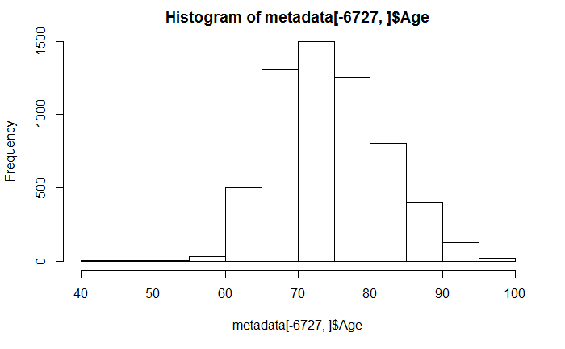

```r
hist(metadata[-6727, ]$Age)
```

```r
unique(metadata$Demographic.ApoE.genotype)
```

```
[1] E3/E3 E4/E3 E4/E4 E4/E2 E3/E2       E2/E2
Levels:  E2/E2 E3/E2 E3/E3 E4/E2 E4/E3 E4/E4
```

```r
metadata$apoe4 <- as.factor(ifelse(metadata$Demographic.ApoE.genotype=="E2/E2"|metadata$Demographic.ApoE.genotype=="E3/E2"|metadata$Demographic.ApoE.genotype=="E3/E3",0,ifelse(metadata$Demographic.ApoE.genotype=="E4/E2"|metadata$Demographic.ApoE.genotype=="E4/E3"|metadata$Demographic.ApoE.genotype=="E4/E4",1,NA)))
metadata %>%
  group_by(apoe4) %>%
  summarise(no_rows = length(apoe4))
```

| apoe4 | no_rows |
| --- | --- |
| 0 | 4155 |
| 1 | 2287 |
| NA | 421 |

Create binary PET status

```r
metadata$PET <- as.factor(ifelse(metadata$Image.PET.Amyloid.PIB_NAV.Status == "Positive" | metadata$Image.PET.Amyloid.Florbetapir.Status== "Positive" | metadata$Image.PET.Amyloid.Flutemetamol.Status == "Positive", "POS", ifelse(metadata$Image.PET.Amyloid.PIB_NAV.Status == "Negative" | metadata$Image.PET.Amyloid.Florbetapir.Status== "Negative" | metadata$Image.PET.Amyloid.Flutemetamol.Status == "Negative", "NEG",NA)))
metadata %>%
  group_by(PET) %>%
  summarise(no_rows = length(PET))
```

| PET | no_rows |
| --- | --- |
| NEG | 1224 |
| POS | 1126 |
| NA | 4513 |

Sort IDs and rename for joining

```r
ids <- data.frame(sort(ids[, 1]))
colnames(ids) <- "AIBL.Id"
as.vector(ids)
```

| AIBL.Id |
| --- |
| 1 |
| 2 |
| 3 |
| 4 |
| 5 |
| 6 |
| 9 |
| 10 |
| 12 |
| 13 |

[output cut: 208 more lines]

```r
missing_samples <- setdiff(1:287, ids) # This wasn't run.
```

Extract metadata for columns of interest and join to IDs

```r
meta1 <- filter(metadata, Collection == "1") %>%
  select(AIBL.Id,
         Demographic.Sex,
         PET,
         apoe4,
         Age) %>%
  right_join(ids, by = "AIBL.Id")
str(meta1)
```

```
'data.frame':   218 obs. of  5 variables:
 $ AIBL.Id        : int  1 2 3 4 5 6 9 10 12 13 ...
 $ Demographic.Sex: Factor w/ 2 levels "Female","Male": NA 2 1 1 2 2 1 2 2 1 ...
 $ PET            : Factor w/ 2 levels "NEG","POS": NA NA 2 2 1 NA NA 2 2 NA ...
 $ apoe4          : Factor w/ 2 levels "0","1": NA 1 2 1 1 1 2 2 2 2 ...
 $ Age            : num  NA 65.2 68.6 84.6 73.1 ...
```

Create subset of data on which to test plots etc., comprising metadata of interest and 100 genes.

```r
test.dat <- exdata[1:100, ] # extract first 100 rows
test.dat <- data.frame(t(test.dat)) # transpose
excols <- colnames(test.dat) # assign column names to vector
excols <- gsub("X", "", excols) # remove the X prefixes
colnames(test.dat) <- excols # replace the column names
exrows <- rownames(test.dat)
exrows <- gsub("X", "", exrows)
rownames(test.dat) <- exrows
test.dat$AIBL.Id <- as.integer(rownames(test.dat))
test.dat <- left_join(meta1, test.dat, by = "AIBL.Id") %>%
  na.omit # exclude rows with NAs
summary(test.dat[,3:4]) # get counts for PET and apoe4
```

```
  PET     apoe4
 NEG:33   0:42
 POS:35   1:26
```

```r
# check that we are left with the right amount of observations
length(which(!is.na(meta1$PET) & !is.na(meta1$apoe4), arr.ind = T))
```

```
[1] 68
```

#### Meeting with JD

*13 December 2017*

*Use the `limma` package to make volcano plots, for both “PET status” (yes or no) and APOE4 (yes or no)

*Do all possible pairwise combinations of the above two, i.e. PET yes & APOE no, APOE yes & PET no, etc.

*Screen out those that are interesting.Once we have a “top table”“, pull out the top genes and go into KEGG, or write a function that finds all the other genes in the pathway for each of the genes.

*Then go back and find the values for those genes - is there a reltaionship or not.

### 1.2. Create initial exploratory plots

Gather expression columns into a `count` column.

```r
consol_test <- test.dat %>%
  gather(-c(AIBL.Id, Demographic.Sex, PET, apoe4, Age), key = gene, value = count)
head(consol_test)
```

|  | AIBL.Id | Demographic.Sex | PET | apoe4 | Age | gene | count |
| --- | --- | --- | --- | --- | --- | --- | --- |
| 1 | 3 | Female | POS | 1 | 68.57769 | 2315554 | 6.202502 |
| 2 | 4 | Female | POS | 0 | 84.63518 | 2315554 | 6.539442 |
| 3 | 5 | Male | NEG | 0 | 73.14168 | 2315554 | 6.310482 |
| 4 | 10 | Male | POS | 1 | 81.86721 | 2315554 | 6.260883 |
| 5 | 12 | Male | POS | 1 | 78.88843 | 2315554 | 6.538413 |
| 6 | 14 | Female | POS | 1 | 65.47023 | 2315554 | 6.303928 |

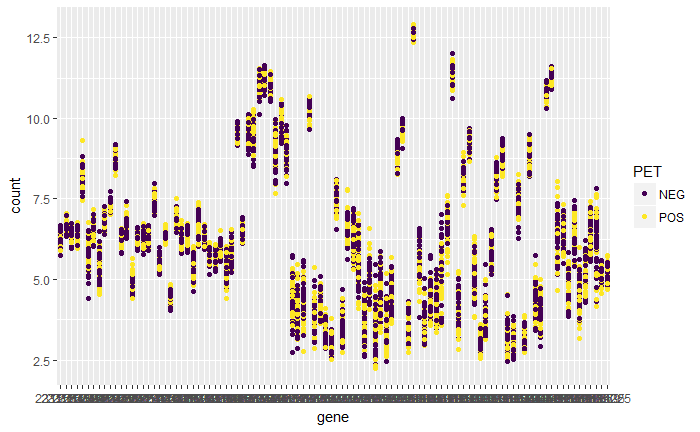

```r
library(tidyverse)
ggplot(consol_test, aes(x = gene, y = count)) +
  geom_point(aes(colour = PET)) +
  viridis::scale_colour_viridis(option = "viridis", discrete = T)
```

The scatterplot is not very informative, so we’ll try a boxplot.

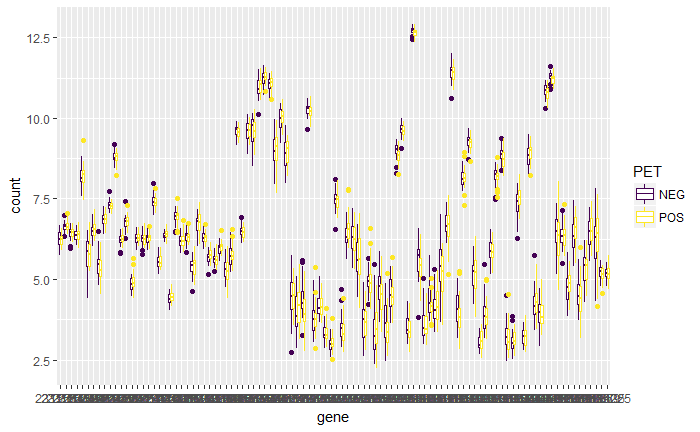

```r
ggplot(consol_test, aes(x = gene, y = count)) +
  geom_boxplot(aes(colour = PET)) +
  viridis::scale_colour_viridis(option = "viridis", discrete = T)
```

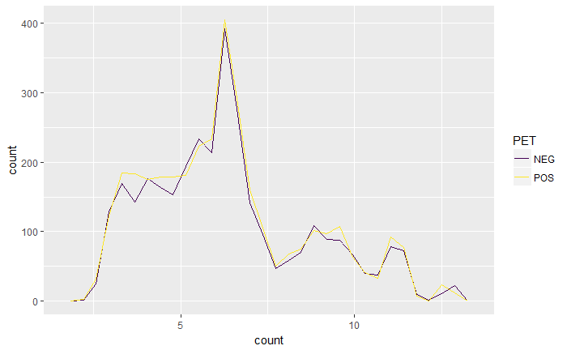

```r
ggplot(consol_test, aes(count)) +
  geom_freqpoly(aes(colour = PET)) +
  viridis::scale_colour_viridis(option = "viridis", discrete = T)
```

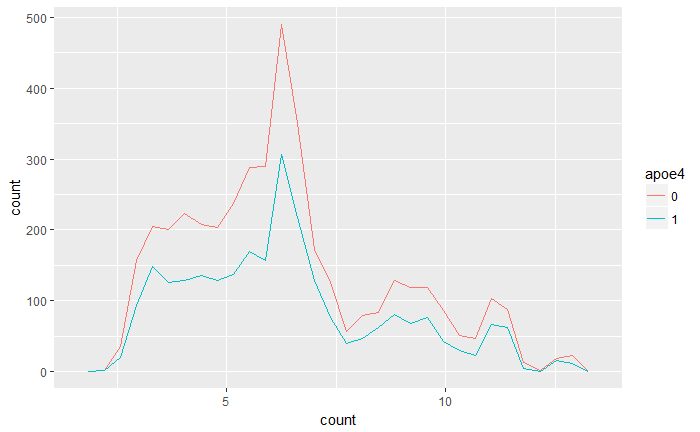

```r
ggplot(consol_test, aes(count)) +
  geom_freqpoly(aes(colour = apoe4))
```

Following this https://www.r-bloggers.com/computing-and-visualizing-pca-in-r/.

Also used this for the plot https://cran.r-project.org/web/packages/ggfortify/vignettes/plot_pca.html

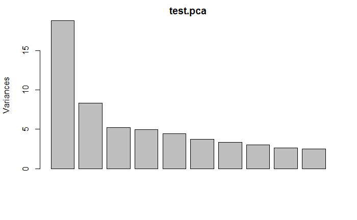

```r
logger <- test.dat[,6:105] # extract expression measurements
logger <- log(logger) # log transform them
logger$AIBL.Id <- test.dat$AIBL.Id # add the AIBL.Id
logger <- left_join(logger, test.dat[,1:5], by = "AIBL.Id") # rejoin metadata
test.pca <- prcomp(logger[1:100], center = T, scale. = T)
plot(test.pca)
```

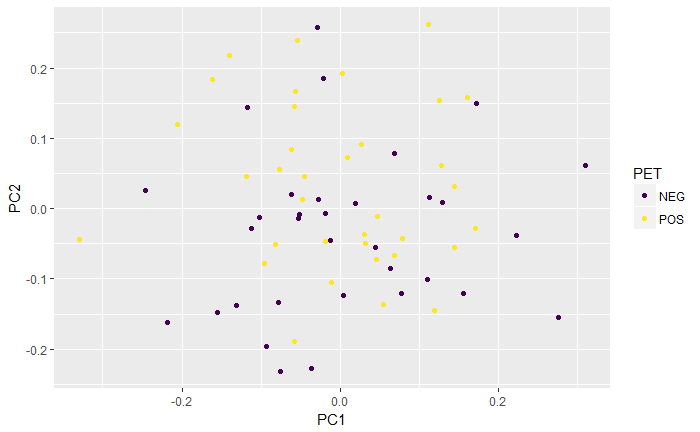

```r
library(ggfortify)
autoplot(test.pca, data = logger, colour = "PET") +
  viridis::scale_colour_viridis(option = "viridis", discrete = T)
```

*18 December 2017*

Plot for whole dataset

```r
exdata1 <- as_tibble(exdata)
exdata1 <- as_tibble(t(exdata1)) # transpose to put samples in rows, genes in columns
colnames(exdata1) <- rownames(exdata) # add genes names
exdata1$AIBL.Id <- as.integer(colnames(exdata)) # add 'AIBL.Id' column
exdata2 <- left_join(meta1, exdata1, by = "AIBL.Id") %>%
  na.omit # add metadata and remove PET and apoe4 columns with 'NA'
rownames(exdata2) <- exdata2$AIBL.Id # to ensure the labels in the plots reflect the AIBL.Ids
# run PCA
pca <- prcomp(exdata2[6:22016], center = T, scale. = T) # run PCA
```

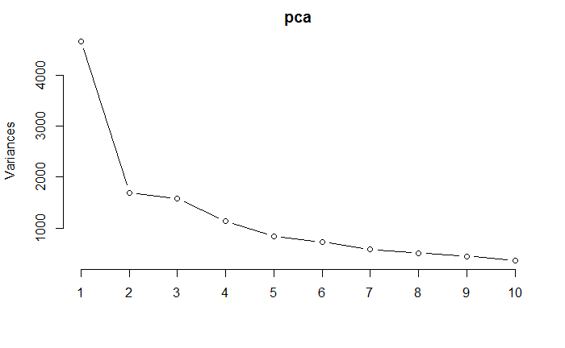

```r
plot(pca, type = "l")
```

Another, better version of the scree plot using the package `factoextra`.

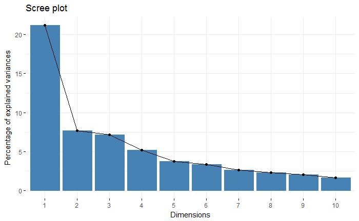

```r
library(factoextra)
fviz_eig(pca)
```

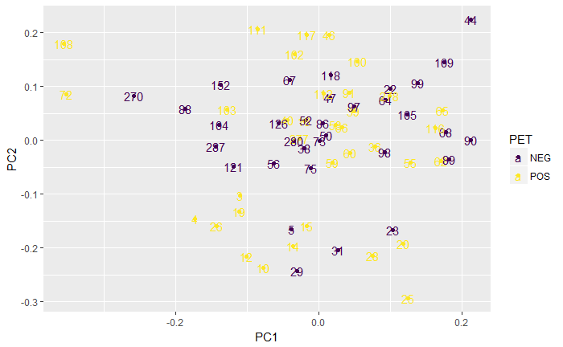

```r
library(ggfortify)
autoplot(pca, data = exdata2, colour = "PET", label = T) +
  viridis::scale_colour_viridis(option = "viridis", discrete = T)
```

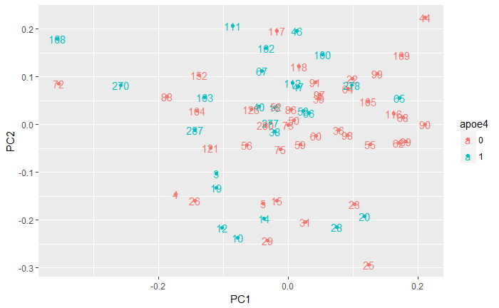

```r
library(ggfortify)
autoplot(pca, data = exdata2, colour = "apoe4", label = T)
```

*Consider excluding outlier individuals with AIBL.Ids 72 and 108.*

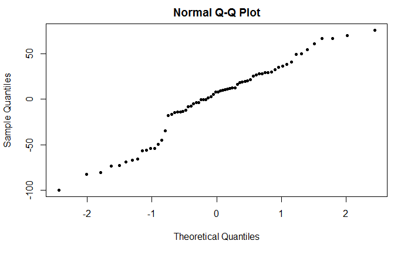

```r
qqnorm(pca$x[,2], pch = 20)
```

First, following the tutorial here: http://bcb.dfci.harvard.edu/~aedin/courses/BiocDec2011/, we will use the `made4` package

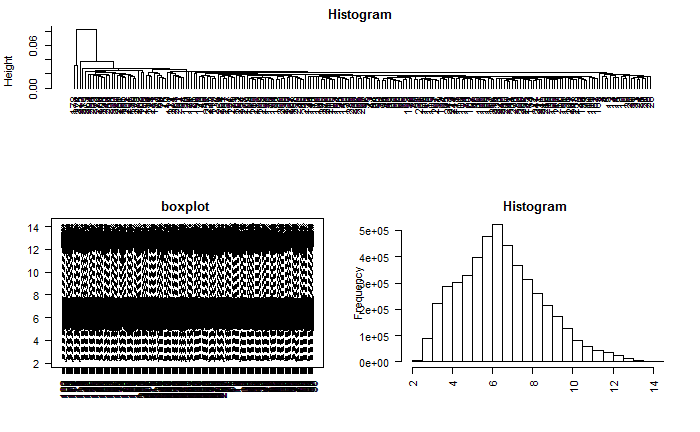

```r
overview(exdata, labels = substring(colnames(exdata), 1, 5))
```

Following the tutorial here: http://www.sthda.com/english/articles/31-principal-component-methods-in-r-practical-guide/118-principal-component-analysis-in-r-prcomp-vs-princomp/, we tried using `princomp()` instead, as that uses ‘spectral decomposition’, which examines the covariances / correlations between variables (whereas `prcomp()` does so between individuals). However that failed, because it requires more observations than variables.

### 1.3. Use `limma` to analyse expression data.

We first create an ‘ExpressionSet’ with genes on rows, and samples on columns, following the guide here: https://www.bioconductor.org/packages/3.7/bioc/vignettes/Biobase/inst/doc/ExpressionSetIntroduction.pdf

```r
summary(pData)
```

```
    AIBL.Id       Demographic.Sex  PET     apoe4       Age
 Min.   :  3.00   Female:35       NEG:33   0:42   Min.   :61.01
 1st Qu.: 34.75   Male  :33       POS:35   1:26   1st Qu.:69.65
 Median : 65.50                                   Median :77.78
 Mean   : 79.75                                   Mean   :75.97
 3rd Qu.:103.25                                   3rd Qu.:80.93
 Max.   :287.00                                   Max.   :92.39
```

Set four pair-wise contrasts of interest and compute the contrasts and moderated t-tests.

Get the genes differentially expressed in each comparison

```r
topTable(fit2, coef = "apoe4_for_PET_yes")
```

|  | logFC | AveExpr | t | P.Value | adj.P.Val | B |
| --- | --- | --- | --- | --- | --- | --- |
| 4011464 | 0.3182717 | 6.265396 | 4.432764 | 3.489943e-05 | 0.6912072 | 0.3695646 |
| 3749672 | 0.9145139 | 5.671916 | 3.994116 | 1.623725e-04 | 0.6912072 | -0.5270021 |
| 3801621 | -0.3268562 | 7.119280 | -3.960257 | 1.822091e-04 | 0.6912072 | -0.5944794 |
| 3945133 | 0.3580702 | 8.778556 | 3.909293 | 2.165168e-04 | 0.6912072 | -0.6955264 |
| 2377094 | -0.3579348 | 7.401698 | -3.843179 | 2.703413e-04 | 0.6912072 | -0.8256536 |
| 3306529 | -0.3996610 | 7.384905 | -3.836671 | 2.762832e-04 | 0.6912072 | -0.8384012 |
| 3721956 | 0.3026178 | 5.904915 | 3.834437 | 2.783519e-04 | 0.6912072 | -0.8427752 |
| 3709590 | 0.2581190 | 6.916362 | 3.831186 | 2.813889e-04 | 0.6912072 | -0.8491382 |
| 2757796 | 0.2219294 | 5.565160 | 3.829872 | 2.826253e-04 | 0.6912072 | -0.8517090 |
| 3468610 | 0.2215128 | 6.132918 | 3.785662 | 3.273927e-04 | 0.7206241 | -0.9379467 |

```r
topTable(fit2, coef = "apoe4_for_PET_no")
```

|  | logFC | AveExpr | t | P.Value | adj.P.Val | B |
| --- | --- | --- | --- | --- | --- | --- |
| 3556990 | 0.3343369 | 4.153127 | 4.655153 | 1.555282e-05 | 0.3312732 | 2.1060915 |
| 2951300 | -0.4344845 | 8.017012 | -4.426811 | 3.565371e-05 | 0.3312732 | 1.4860517 |
| 3438581 | 0.4343748 | 6.265462 | 4.319635 | 5.227351e-05 | 0.3312732 | 1.1998099 |
| 3817698 | 0.4179067 | 4.638645 | 4.172960 | 8.759393e-05 | 0.3312732 | 0.8134928 |
| 3171441 | 0.5558372 | 4.358374 | 4.017931 | 1.496822e-04 | 0.3312732 | 0.4124910 |
| 3840253 | 0.3862734 | 4.237659 | 3.994774 | 1.620083e-04 | 0.3312732 | 0.3532751 |
| 3981931 | 0.4550528 | 5.037606 | 3.993286 | 1.628324e-04 | 0.3312732 | 0.3494782 |
| 3724969 | 0.2915543 | 5.361474 | 3.991936 | 1.635841e-04 | 0.3312732 | 0.3460317 |
| 3852735 | 0.3444322 | 6.392720 | 3.979940 | 1.704106e-04 | 0.3312732 | 0.3154400 |
| 3913525 | 0.2819620 | 6.311619 | 3.974590 | 1.735431e-04 | 0.3312732 | 0.3018108 |

```r
topTable(fit2, coef = "PET_for_apoe4_yes")
```

|  | logFC | AveExpr | t | P.Value | adj.P.Val | B |
| --- | --- | --- | --- | --- | --- | --- |
| 3959411 | -0.3099765 | 5.480845 | -3.822211 | 0.0002899388 | 0.9812665 | -1.861898 |
| 3852735 | -0.3375512 | 6.392720 | -3.805514 | 0.0003065095 | 0.9812665 | -1.884880 |
| 2906990 | -0.6031612 | 5.389308 | -3.750586 | 0.0003676590 | 0.9812665 | -1.960165 |
| 3556990 | -0.2733890 | 4.153127 | -3.713913 | 0.0004147994 | 0.9812665 | -2.010149 |
| 2899176 | 0.4926297 | 6.259814 | 3.676263 | 0.0004691701 | 0.9812665 | -2.061223 |
| 3724969 | -0.2721350 | 5.361474 | -3.635377 | 0.0005358882 | 0.9812665 | -2.116403 |
| 2457988 | 0.4766344 | 7.904995 | 3.499862 | 0.0008276279 | 0.9812665 | -2.297084 |
| 3913525 | -0.2518393 | 6.311619 | -3.463588 | 0.0009282466 | 0.9812665 | -2.344847 |
| 3334290 | -0.3914554 | 5.211136 | -3.455430 | 0.0009524180 | 0.9812665 | -2.355551 |
| 3939952 | -0.7727171 | 4.486039 | -3.443147 | 0.0009899402 | 0.9812665 | -2.371645 |

```r
topTable(fit2, coef = "PET_for_apoe4_no")
```

|  | logFC | AveExpr | t | P.Value | adj.P.Val | B |
| --- | --- | --- | --- | --- | --- | --- |
| 3275214 | 0.3840619 | 2.990037 | 3.720793 | 0.0004055374 | 0.9999562 | -0.9454196 |
| 3551782 | -0.4042359 | 3.477249 | -3.405396 | 0.0011142118 | 0.9999562 | -1.5624290 |
| 2565207 | 0.3642141 | 3.398842 | 3.369151 | 0.0012472835 | 0.9999562 | -1.6312709 |
| 3991006 | 0.2034971 | 3.335433 | 3.285372 | 0.0016144794 | 0.9999562 | -1.7886545 |
| 2359444 | 0.2143229 | 3.549048 | 3.266502 | 0.0017101838 | 0.9999562 | -1.8237612 |
| 3725922 | -0.4859447 | 7.465802 | -3.225604 | 0.0019362116 | 0.9999562 | -1.8994089 |
| 3470312 | 0.3890348 | 6.010328 | 3.217498 | 0.0019842183 | 0.9999562 | -1.9143301 |
| 3725813 | -0.2901400 | 9.135281 | -3.209149 | 0.0020348301 | 0.9999562 | -1.9296734 |
| 3475146 | -0.2948346 | 3.267793 | -3.207273 | 0.0020463674 | 0.9999562 | -1.9331173 |
| 2536374 | -0.4683972 | 6.970914 | -3.121272 | 0.0026461646 | 0.9999562 | -2.0895914 |

```r
library(cluster)
clara.dat <- test.dat[,6:105]
cl.test <- clara(clara.dat, 2)
autoplot(cluster::clara(clara.dat, 2))
```

```r
library(caret)
trans <- preProcess(logger[,1:100],
                    method = c("BoxCox", "center", "scale", "pca"))
```

#### Analyse test data with `limma` package

*15 December 2017*

```r
ggplot(data = test.dat) +
  geom_point(mapping = aes(x = AIBL.Id, y = test.dat$`2315554`, colour = Image.PET.Amyloid.PIB_NAV.Status))
```

#### Create PCA plots

Using the ‘dummies’ package, create a new data frame converting all variables into integers.

```r
test.dat1 <- dummy.data.frame(test.dat, names = c("Demographic.Sex",
                                                  "Image.PET.Amyloid.PIB_NAV.Status",
                                                  "Demographic.ApoE.genotype",
                                                  "Progress.Summary.Date.of.NP.assessment"))
```

Divide the new data into test and train

```r
pca.train <- test.dat1[1:nrow(test.dat1),]
pca.test <- test.dat1[-(1:nrow(test.dat1)),]
```

Run principal component analysis

```r
prin_comp <- prcomp(pca.train, scale. = T)
```

test.dat2 <- exdata[1:100, ] test.dat2 <- data.frame(t(test.dat2))

prin_comp <- prcomp(test.dat2, scale. = T) names(prin_comp)

# outputs the mean of variables

prin_comp$center

# outputs the standard deviation of variables

prin_comp$scale

# outputs the principal component loading

prin_comp$rotation prin_comp$rotation[1:5,1:4]

dim(prin_comp$x)

biplot(prin_comp, scale = 0) std_dev <- prin_comp$sdev pr_var <- std_dev^2 pr_var[1:10]

prop_varex <- pr_var/sum(pr_var) prop_varex[1:20]

plot(prop_varex, xlab = “Principal Component”, ylab = “Proportion of Variance Explained”, type = “b”)

plot(cumsum(prop_varex), xlab = “Principal Component”, ylab = “Cumulative Proportion of Variance Explained”, type = “b”) ***